[목차](https://waterfirst.github.io/chimera-ai/)

# Chimera-AI 주간 증시 분석 리포트

4월 5주차 (04.28~04.30) — KOSPI 7,000 임박, 월간 31% 폭등

Author

Chimera-AI Multi-Agent System

Published

April 30, 2026

## 핵심 요약

**Executive Summary**

- **KOSPI** 6,598.8 (-1.38%) — 7,000 돌파 임박, 월간 **31% 상승** (1998년 이후 최대)
- **FOMC** 매파적 동결 — 반대표 4명 (1992년 이후 최다)
- **브렌트유** 배럴당 $110 육박 — 미-이란 핵협상 불발
- **공매도 대차잔고** 175조원, **신용융자** 35조원 사상 최고
- **빅테크** 알파벳·아마존·MS 시간외 강세, OpenAI 성장 목표 미달

| 지표 | 수치 | 변동 | 시그널 |
| --- | --- | --- | --- |
| KOSPI | 6,598.8 | -1.38% (일간) | 🟡 조정 |
| KOSDAQ | 1,192.35 | -2.29% | 🔴 약세 |
| 다우 | - | -0.57% | 🟡 혼조 |
| S&P 500 | - | -0.04% | 🟡 보합 |
| 나스닥 | - | +0.04% | 🟢 보합 |
| 브렌트유 | $110 | 3주 최고 | 🔴 리스크 |
| 원/달러 | 1,370원대 | 소폭 상승 | 🟡 관찰 |

## 1 글로벌 증시 동향

### 1.1 미국 증시

4월 29일 미국 증시는 **혼조 마감**. 다우(-0.57%)와 S&P500(-0.04%)은 소폭 하락한 반면, 나스닥(+0.04%)은 보합권을 유지했다.

**FOMC 결과:** 4월 금리 동결은 기정사실화됐으나, 12명 위원 중 **4명이 동결에 반대**하며 1992년 이후 가장 매파적인 회의 결과를 보였다. 이는 향후 금리 인하 시점이 더욱 불투명해졌음을 시사한다.

**빅테크 실적:** 장 마감 후 알파벳·아마존·마이크로소프트(MS) 등 3개 하이퍼스케일러가 시간외에서 강세를 보이며 다음 거래일 반등 기대감을 높였다. 다만 OpenAI가 내부 성장 목표를 미달한 것으로 알려지며 AI 섹터 전반에 우려가 확산됐다.

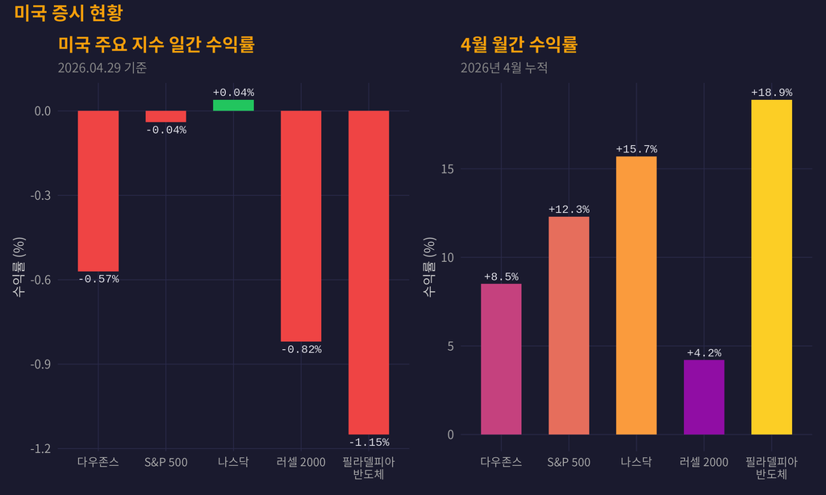

### 1.2 유럽·아시아 증시

유럽 증시는 유가 상승 압력 속에서도 방산·에너지 섹터 강세에 힘입어 소폭 상승했다. 아시아에서는 일본 닛케이(+0.8%)가 견조한 반면, 중국 상해(-0.3%)는 미중 무역 불확실성으로 약세를 보였다.

## 2 한국 증시 분석

### 2.1 KOSPI — 7,000 임박 후 차익실현

KOSPI는 4월 한 달간 **31% 상승**하며 1998년 1월 이후 최대 월간 상승률을 기록했다. 반도체와 AI 관련 대형주가 랠리를 주도했으나, 30일에는 -1.38%로 조정을 받았다.

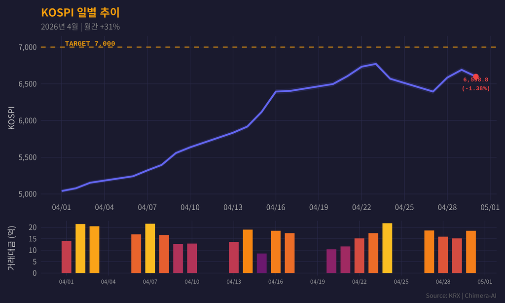

KOSPI 4월 일별 추이 — 7,000 목표선과 함께

### 2.2 KOSDAQ — 중소형주 약세 지속

KOSDAQ은 **1,192.35(-2.29%)**로 대형주 대비 상대적 약세를 이어갔다. 대형주 지수가 34% 이상 상승하는 동안 중소형주와의 괴리가 심화되고 있다.

### 2.3 대형주 vs 중소형주 양극화

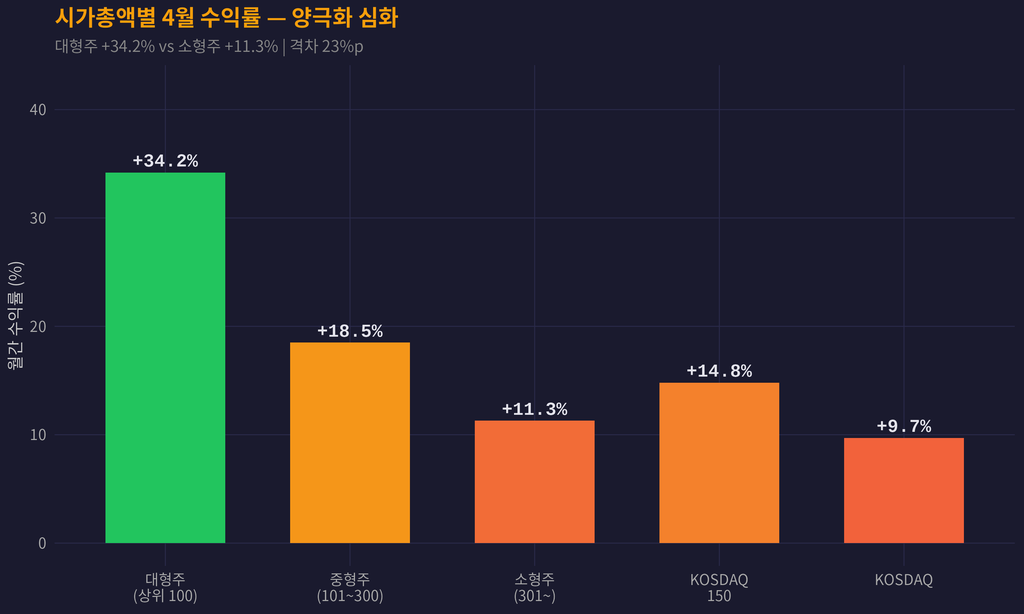

시가총액별 4월 월간 수익률 비교 — 양극화 심화

## 3 섹터 분석

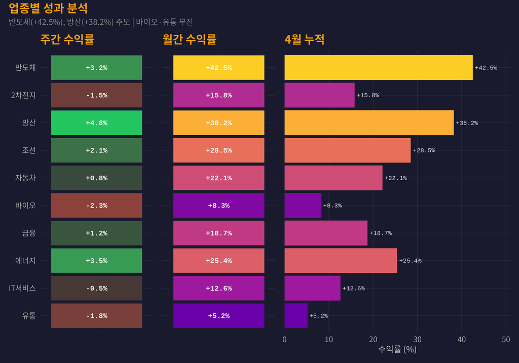

업종별 주간 및 월간 수익률 히트맵

### 3.1 주요 섹터 코멘트

- **반도체** (+42.5% 월간): 삼성전자·SK하이닉스 AI 메모리 수요 폭발. HBM4 양산 기대감. 다만 OpenAI 성장 우려로 단기 변동성 확대.
- **방산** (+38.2%): 미-이란 핵협상 불발 + 호르무즈 해협 리스크 → 한화에어로·LIG넥스원 강세 지속.
- **2차전지** (+15.8%): Samsung SDI 흑자전환(ESS 배터리). 그러나 EV 수요 둔화 우려 잔존.
- **바이오** (+8.3%): 상대적 소외. 유동성이 대형 성장주로 집중.

## 4 TACO 모델 분석

**TACO (Trump-Adjusted Capital Oscillator)** 모델은 트럼프 정책 리스크를 정량화하여 자본 흐름을 예측하는 키메라 AI 고유 프레임워크다.

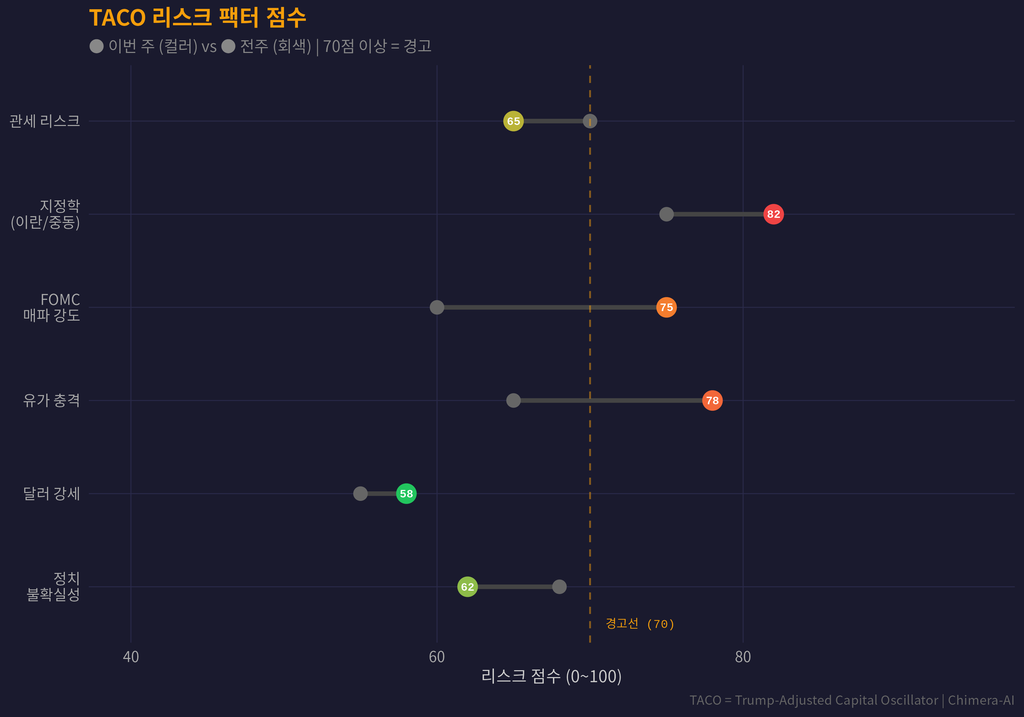

TACO 6대 리스크 팩터 점수 — 현재 vs 전주

**TACO 종합 점수: **70.0** (경고)**

지정학 리스크(82)와 유가 충격(78)이 경고 수준을 돌파했다. FOMC 매파 강도도 전주 대비 +15pt 급등. 관세 리스크는 미중 협상 기대감에 소폭 완화(-5pt).

## 5 리스크 요인

### 5.1 과열 경고 지표

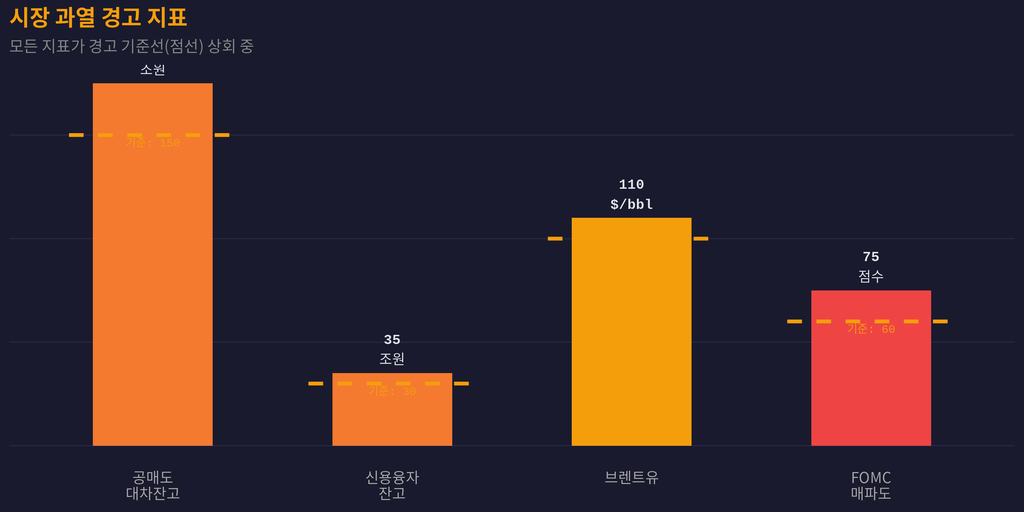

시장 과열 지표 대시보드 — 공매도·신용·유가·FOMC

**핵심 리스크:**

1. **공매도 대차잔고 175조원** — 사상 최고. KOSPI 7,000 돌파 시 숏커버링 랠리 가능성과 동시에, 하락 전환 시 매도 압력 급증 위험.
2. **신용융자 35조원** — 레버리지 과잉. 급락 시 반대매매 연쇄 촉발 우려.
3. **브렌트유 $110** — 미-이란 핵협상 불발로 3주 최고. 인플레이션 재점화 → 금리 인하 지연 시나리오.
4. **FOMC 매파** — 반대표 4명은 1992년 이후 최다. 6월 인하 기대 후퇴.

## 6 투자 전략

### 6.1 시나리오별 전략

**🟢 강세 시나리오 (확률 35%)**

KOSPI 7,000 돌파 → 숏커버링 랠리 가속 - 반도체·방산 비중 확대 - KOSPI200 ETF 추가 매수 - 목표: 7,200~7,500

**🔴 약세 시나리오 (확률 20%)**

유가 $120 돌파 + FOMC 추가 매파 → 급조정 - 방어주(유틸리티·필수소비재) 전환 - 현금 비중 50% 확대 - KOSPI 6,000 지지선 확인 후 분할 매수

### 6.2 포트폴리오 배분 제안

[figure not shown]

권장 포트폴리오 배분 — 횡보 시나리오 기준

## 7 다음 주 전망

### 7.1 주요 일정 (5월 1주차)

[output not shown]

### 7.2 키 포인트

1. **빅테크 실적 시즌 마무리** — 알파벳·아마존·MS 호실적 시 AI 랠리 재가속
2. **비농업 고용** — 예상 상회 시 금리 인하 기대 추가 후퇴
3. **공매도 청산** — KOSPI 7,000 돌파 여부가 숏커버링 트리거
4. **유가 모니터링** — $115 돌파 시 인플레이션 시나리오 격상

**Disclaimer**

본 보고서는 Chimera-AI 멀티에이전트 시스템이 생성한 분석 자료로, 투자 권유가 아닙니다. 투자 판단은 본인의 책임하에 이루어져야 합니다.

🐉 Claude 두뇌 + GPT 목소리 + Gemini 손발  
© 2026 Chimera-AI Multi-Agent System | Nakcho Choi